# Adatvizualizáció I.

### Tengely skálák, színskálák

Az eddigiek során minden esetben elfogadtuk a ggplot2 automatikus beállításait a tengelyek formázásával kapcsolatban, a legtöbb esetben viszont módosítani szeretnénk ezeken. Azt szeretnénk, ha metrikus változóknál a két tengely az origónál metszené egymást, állítani akarunk a maximum értéken és a lépésközökön, esetleg meg akarjuk változtatni a színskálák értékeit.

A skálák leggyakrabban használt típusai a változó típusától függően:

- Diszkrét skála: `scale_x_discrete()`, `scale_y_discrete()`
- Folytonos skála: `scale_x_continous()`, `scale_y_continous()`
- Dátum skála: `scale_x_date()`, `scale_y_date()`
- Szín skála: `scale_color_discrete()`, `scale_color_continous`

Az eddig látott plotokon az x és y változóhoz tartozó skálákat és a színskálákat a ggplot automatikusan hozta létre.

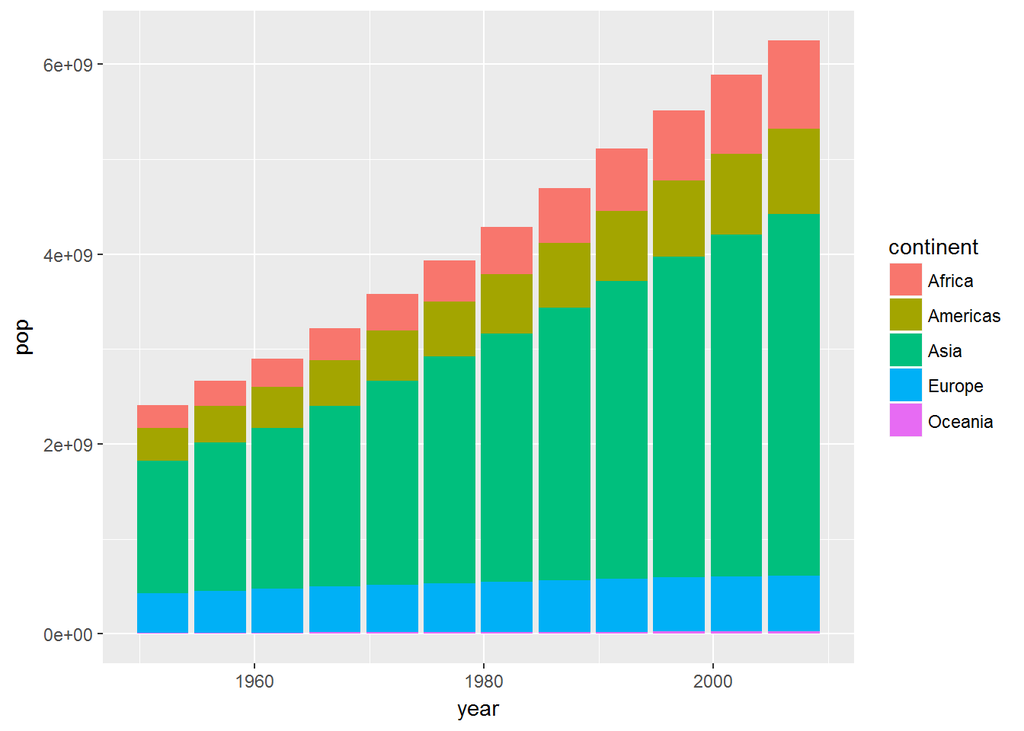

```r
# A kontinensek népesség szerinti megoszlása a mintában az egyes években
ggplot(data = gapminder) +
  geom_col(mapping = aes(x = year, y=pop, fill = continent))
```

Az előző ggplot kód a következő kódnak felel meg a háttérben:

```r
# A kontinensek népesség szerinti megoszlása a mintában az egyes években
ggplot(data = gapminder_continent_pop_summary) +
  geom_col(mapping = aes(x = year, y=continent_total_pop_m, fill = continent)) +
  scale_x_continuous() + # a year integer a data.frame-ben
  scale_y_continuous() + # a pop változó integer
  scale_color_discrete() # a kontinens szerint színezünk, ami diszkrét változó
```

A következő példában a fenti chart y tengelyén beállítjuk a lépésközöket, állítunk a tengelyek maximum és minimum értékén, és másik színskálát adunk meg.

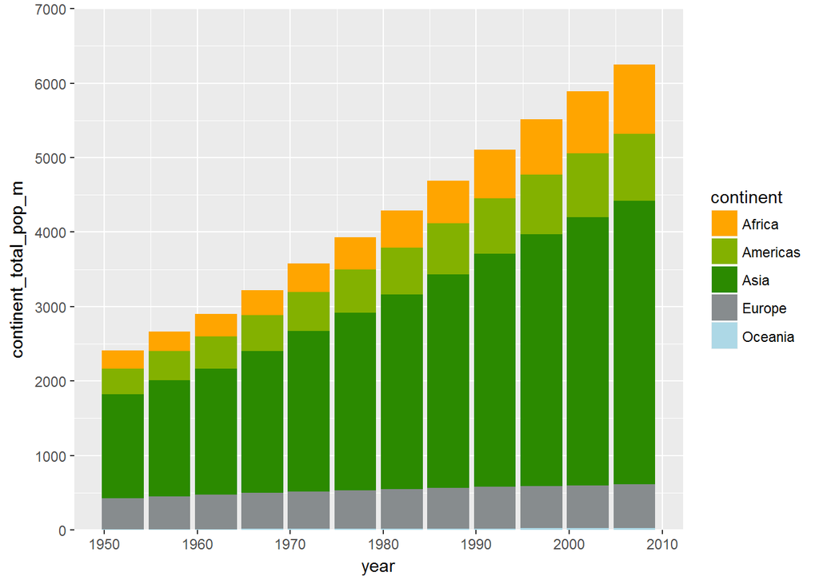

```r
# A kontinensek népesség szerinti megoszlása a mintában az egyes években
ggplot(data = gapminder_continent_pop_summary) +
  geom_col(mapping = aes(x = year, y=continent_total_pop_m, fill = continent)) +
  # Az x tengelyen 1950 és 2010 között 10 éves lépésköz
  scale_x_continuous(breaks = seq(1950,2010,by=10)) +
  # Az y tengely min.: 0, max: 7 Mrd, 0-7 Mrd között 10 éves lépésköz
  scale_y_continuous(limits = c(0,7000), expand = c(0,0), breaks = seq(0,7000,by=1000)) +
  # Egyedileg megadott diszkrét szín értékek
  scale_fill_manual(values = c("#ffa500", "#83b100","#2b8a00","#878c8e","#add8e6"))
```

A `breaks` paraméterben az osztópontokat tudjuk megadni vektorként, a `limits` paraméterben a tengely minimum és maximum értékét, az `expand = c(0,0)` beállítással tudjuk biztosítani, hogy az oszlopok a 0 ponttól induljanak. A színskálát, ha a színezés diszkrét skálától függ, akkor manuális skála megadásával tudjuk módosítani. Másik skálát kell használnunk, ha a kitöltéshez (fill), vagy ha a körvonal színéhez (color) szeretnénk új skálát rendelni. A kitöltés skálája a `scale_fill_manual()` függvénnyel, a körvonalé `scale_color_manual()` függvénnyel adható meg. Ha folytonos változóhoz szeretnénk színskálát rendelni, akkor választhatunk olyan skálát, ahol a kezdő és a végpont színeit kell megadnunk, a köztes színek pedig automatikusan legenerálódnak, például `scale_colour_gradient()`, más skáláknál egy vagy több köztes osztópont színét is megadhatjuk, például `scale_colour_gradient2()`.

Maguk a színkódok többféle módon is megadhatóak, például:

- Ahogy azt korábban láttuk a szín nevének megadásával pl. “red”. A `colors()` paranccsal kérhető le az összes elérhető színelnevezés. [Online](http://research.stowers.org/mcm/efg/R/Color/Chart/) az elnevezésekhez tartozó színpalettákat is megtaláljátok
- Hexadecimális kóddal, erre a fenti kód nyújt példát
- RGB kóddal, az `rgb()` függvény segítségével, pédául a tiszta kék szín kódja: `c(rgb(0, 0, 255, maxColorValue = 255)`

A megfelelő színek megtalálásában segítenek a ggplot2-n belül megtalálható beépített színskálák, úgy mint a `scale_colour_brewer()`, illetve számos online tool is elérhető, ami segít a színskálák összerakásában. A [Chroma.js](https://gka.github.io/palettes/) például pár megadott színkód vagy színnév alapján generál szekvenciális (inkább folytonos adatokhoz alkalmas) és divergens (inkább diszkrét adatokhoz alkalmas) színskálát.

### Feliratok és címkék

A tengelyek osztópontjainak feliratát a `labels()` függvénnyel állíthatjuk be. A tengelyfeliratok számának azonosnak kell lennie az osztópontok számával, de a felirat lehet üres is. Az előző charton tovább dolgozva az y tengely osztópontjainak feliratait milliárdokban fogjuk bemutatni. Ehhez először egy formázó függvényt definiálunk, amit később felhasználunk a chartban. Ezen kívül feliratozzuk az x és az y tengelyt, adatcímkézzük az oszlopokat, címet adunk a chartnak, és mégváltoztatjuk a jelmagyarázat címét.

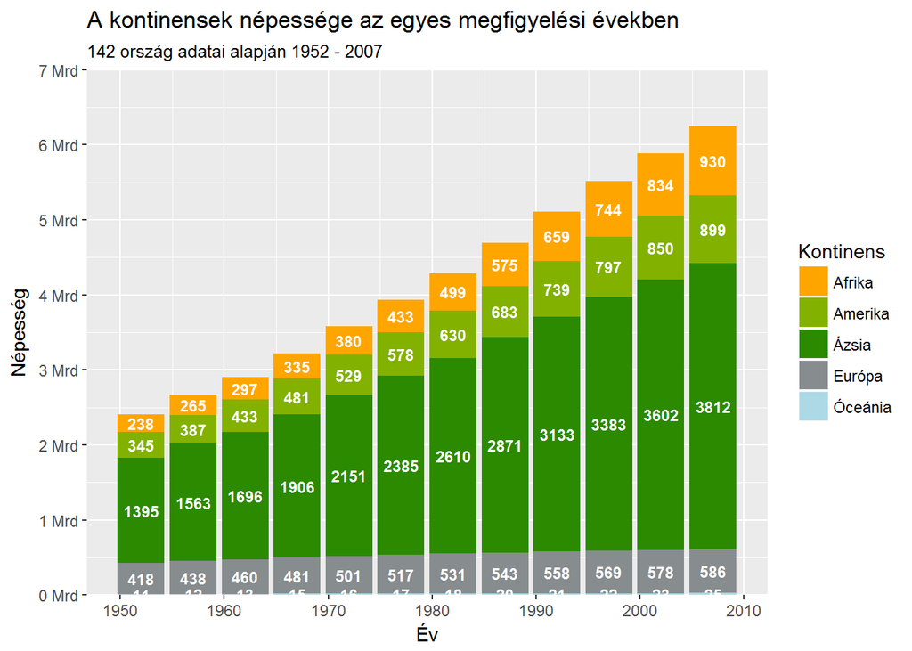

```r
# formázáshoz használt függvény definiálása
# e.g.: num_b_2_digits(1100) eredménye "1.1 Mrd"
num_m2b_2_digits <- function(num){
  paste(format(num/1000, digits = 3),"Mrd")
}

# A kontinensek népesség szerinti megoszlása a mintában az egyes években
# A ggplot() és geom() fvt. átrendeztük, hogy ne kelljen aes()-t ismételni
# group=continent beállítás kell, hogy a label-ek a megfelelő helyre kerüljenek
ggplot(data = gapminder_continent_pop_summary, aes(x = year, y=continent_total_pop_m, group=continent)) +
  geom_col(mapping = aes(fill = continent)) +
  scale_x_continuous(breaks = seq(1950,2010,by=10)) +
  scale_y_continuous(
    limits = c(0,7000),
    expand = c(0,0),
    breaks = seq(0,7000,by=1000),
    # a labels függvény alkalmazza a formázást az összes osztópont feliratra
    labels = num_m2b_2_digits) +
  # A kitöltéshez tartozó jelmagyarázat a hozzá tartozó színskálán belül módosítható
  scale_fill_manual(values = c("#ffa500", "#83b100","#2b8a00","#878c8e","#add8e6"),
                    name = "Kontinens",
                    labels = c("Afrika","Amerika","Ázsia","Európa","Óceánia")) +
  # Címkék hozzáadása
  geom_text(mapping = aes(label=continent_total_pop_m),
            position=position_stack(vjust = 0.5),
            size=3,
            color="white",
            fontface="bold") +
  # Címek és tengelyfeliratok
  ggtitle("A kontinensek népessége az egyes megfigyelési években",
          subtitle = "142 ország adatai alapján 1952 - 2007") +
  xlab("Év") +
  ylab("Népesség")
```

### Témák

A plot megjelenésén számos további elem módosítható, ezek többségükben a `theme()` függvényen keresztül érhtőek el. A következő példában a jelmagyarázatot a chart alá helyezzük, eltüntetjük az osztópontok jelölőit az y tengelyen és a chart hátterét, és szürkére színezzük az x tengelyt.

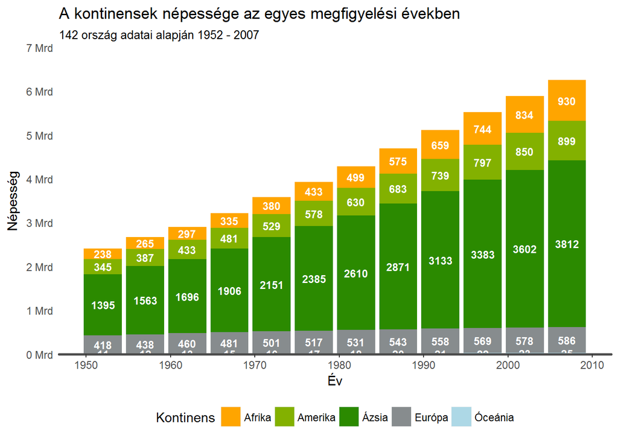

```r
# formázáshoz használt függvény definiálása
# e.g.: num_b_2_digits(1100) eredménye "1.1 Mrd"
num_m2b_2_digits <- function(num){
  paste(format(num/1000, digits = 3),"Mrd")
}

# A kontinensek népesség szerinti megoszlása a mintában az egyes években
ggplot(data = gapminder_continent_pop_summary, aes(x = year, y=continent_total_pop_m, group=continent)) +
  geom_col(mapping = aes(fill = continent)) +
  scale_x_continuous(breaks = seq(1950,2010,by=10)) +
  scale_y_continuous(
    limits = c(0,7000),
    expand = c(0,0),
    breaks = seq(0,7000,by=1000),
    labels = num_m2b_2_digits) +
  scale_fill_manual(values = c("#ffa500", "#83b100","#2b8a00","#878c8e","#add8e6"),
                    name = "Kontinens",
                    labels = c("Afrika","Amerika","Ázsia","Európa","Óceánia")) +
  geom_text(mapping = aes(label=continent_total_pop_m),
            position=position_stack(vjust = 0.5),
            size=3,
            color="white",
            fontface="bold") +
  ggtitle("A kontinensek népessége az egyes megfigyelési években",
          subtitle = "142 ország adatai alapján 1952 - 2007") +
  xlab("Év") +
  ylab("Népesség") +
  theme(
    legend.position = "bottom", # a legend a chart alatt foglal helyet
    axis.ticks.y = element_blank(), # üres elem, vagyis eltűnik az osztópont jelölő
    axis.line.x = element_line(colour = "grey30", size = 1), # az x tengely szürke
    panel.background = element_blank() # üres elem, vagyis eltűnik a háttér
  )
```

### Sablonok készítése

Ha a chartok egyes elemei állandóak, például azonos a betű típus vagy a színskálák színei, akkor érdemes lehet sablont készíteni a ggplot2 ábrákhoz, ami azután minden ábrához használható. Erről például ezen a [linken](https://www.ildiczeller.com/2017/10/15/custom-ggplot2-theme/) található leírás.

Emellett kisebb munkát igényel, és érdemes lehet a gyakran használt segédfüggvényeket, mint például a formázáshoz használt `num_m2b_2_digits()` függvény, egy külön scriptben elmenteni, ami aztán az új scriptek elején betölthető a `source()` függvénnyel, és felhasználható az új chartokhoz.

## Házi feladat

1. A plot függvény segítségével állítsatok elő vonaldiagramot a várható élettartam alakulásáról Ausztriában 1990 után. A vonal színe legyen az alapbeállítástól eltérő.
2. Ábrázoljátok a 2000-es évtől kezdve Európában a medián és az átlagos várható élettartam alakulását évenként.
   - *Hint:* a medián és az átlagos várható élettartam két különböző rétegben ábrázolható.
3. **A pie chart rossz** vagy csak [nagyon ritkán jó](https://medium.com/@KristinHenry/in-defense-of-pie-charts-and-why-you-shouldnt-use-them-df2e8ccb5f76). A következő [blog bejegyzés](http://www.storytellingwithdata.com/blog/2014/08/design-with-audience-in-mind) egy pie chart makeover-ről szól. Az új vizualizációt a cikkben Excelben készítik el, készítsetek hasonló ábrát R-ben. Az adatok letölthetőek a cikk végén található [linkről](https://www.dropbox.com/s/3ctpw1h1mje2fl0/USA%20Today%20Diversity%20Remake.xlsx?dl=0#)
   - *Hint1:* Az adatokat érdemes .txt vagy .csv formátumú fájlba másolni, majd `read.table()`, `read.csv()` vagy `read.delim()` függvénnyel beolvasni
   - *Hint2:* A megoszlásra vonatkozó adatokat *%* formázás nélkül olvassátok be, úgy, hogy a beolvasást követően numerikus formátumú legyen. Figyeljetek a tizedes vessző/pont beállításra, ha ez nem stimmel, az R szöveges mezőként fogja felismerni az adatokat. Ehhez a `read.x()` függvényekben a `dec` paramétert kell helyesen beállítani.
   - *Hint3:* Az órán vertikális oszlopdigramokat láttunk, a feladatban viszont horizontális diagramot kell létrehozni. Ehhez meg kell fordítani a tengelyt a `coord_flip()` függvénnyel. A [hivatalos dokumentációban](http://ggplot2.tidyverse.org/reference/geom_bar.html) találtok ehhez leírást és példát is.
   - *Hint4:* Ha nagyon elakadtok a feladatmegoldás során, akkor a következő [tutorial](http://rstudio-pubs-static.s3.amazonaws.com/4305_8df3611f69fa48c2ba6bbca9a8367895.html) egy egészen hasonló problémát old meg

## Források

[1] H. Wickham and G. Grolemund. *R for Data Science: Import, Tidy, Transform, Visualize, and Model Data*. 1 edition. Sebastopol, CA: O’Reilly Media, jan.. 2017. ISBN: 9781491910399.